# Running R code in parallel

## Introduction

Much of the following is adapted from some [course notes by Josh Errickson](http://dept.stat.lsa.umich.edu/~jerrick/courses/stat701/notes/parallel.html) and an [r-bloggers post by Max Gordon](https://www.r-bloggers.com/how-to-go-parallel-in-r-basics-tips/). There is also a lot of info in vignettes for the R packages [`parallel`](https://stat.ethz.ch/R-manual/R-devel/library/parallel/doc/parallel.pdf) and [`doParallel`](https://cran.r-project.org/web/packages/doParallel/vignettes/gettingstartedParallel.pdf).

There are a lot of situations where you might want to run multiple R functions or perform multiple calculations. Running your R code in parallel refers to running these functions side-by-side (at the same time) rather than running each in turn. A particular analysis can be more or less suited to parallelisation, with some analyses being “embarrassingly” parallel (really easy to run in parallel) and others being inherently serial (impossible to run in parallel). It’s possible (and usually easy) to run R code in parallel when the different functions or calculations are completely independent of one another. By contrast, it’s impossible to run R code in parallel when the different steps in your analysis have to be called one at a time and each step depends on the outputs of the previous step. Many problems lie somewhere between these two extremes, in which case there can still be some benefit to running parts of your analysis in parallel.

## Examples

### A serial problem

Simulating an autoregressive process is an inherently serial problem. An autoregressive process is a time-series whose value at each point in time depends on the value at the previous point in time. More formally, we want to simulate a process $X_{t}$ that follows the equation $X_{t} = \rho X_{t-1} + Z_{t}$, where $\rho$ is a constant and $Z_{t}$ are IID Gaussian random variates. We can do this in R with the following code

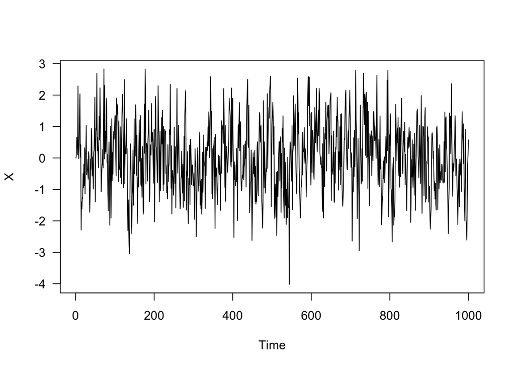

```r
n <- 1000   # number of time steps
rho <- 0.5  # autoregressive parameter
x <- vector('numeric', length = n)  # create an empty vector to store the simulated data
x[1] <- 0.0  # initialise the autoregressive process at zero
# loop over all time steps to calculate the value of x at each time step
for (i in 2:n) {
  x[i] <- rho * x[i - 1] + rnorm(1, mean = 0.0, sd = 1.0)
}
# plot the simulated autoregressive process
plot(ts(x), ylab = 'X', las = 1)
```

Here, each value of $X_{t}$ depends on the previous timestep $X_{t-1}$. In this case, it’s impossible to simulate the multiple values of $X_{t}$ in parallel (at the same time). While we don’t really need a speed-up in this particular example, this same situation arises in the MCMC/HMC samplers used in statistical-inference software (e.g. JAGS, BUGS, Stan, greta), where each step can be much more complex.

### A parallel problem

Fitting multiple regression models to different data sets is an embarrassingly parallel problem. One example might be fitting a logistic regression model to data for several different species. Here, our goal is to fit the model
$$\begin{equation}
Y_{i} \sim Bernoulli(\pi_{i}) \\
logit(\pi_{i}) = \mathbf{X_{i}} \boldsymbol{\beta}
\end{equation}$$

for several different species. Here, $Y_{i}$ denotes presence (1) or absence (0) of a given species in site $i$, $\pi_{i}$ is the probability of presence for that species in site $i$, $\mathbf{X_{i}}$ is a vector of predictor variables in site $i$, and $\boldsymbol{\beta}$ is a vector of regression coefficients for a given species. We can fit this model with the `glm` function in R. First, we need to simulate some data.

```r
n <- 1000  # number of observations
nsp <- 10  # number of species
npred <- 5 # number of predictor variables
x <- matrix(rnorm((n * (npred - 1))), ncol = (npred - 1))  # simulate some predictor data
x <- cbind(rep(1, nrow(x)), x)  # add an intercept
beta_real <- matrix(rnorm(nsp * npred), ncol = nsp) # simulate some regression coefs
y <- matrix(NA, nrow = n, ncol = nsp)  # prepare an empty matrix for the response data
for (i in 1:nsp) {
  # fill the response matrix with a 1 or 0 (presence/absence) for each species,
  y[, i] <- rbinom(n = n, size = 1, prob = plogis(x %*% beta_real[, i]))
}
# add some column and row names to the simulated data
colnames(x) <- c('Intercept', paste0('Predictor', 1:(npred - 1)))
rownames(x) <- paste0('Site', 1:n)
colnames(y) <- paste0('Species', 1:nsp)
rownames(y) <- rownames(x)
colnames(beta_real) <- colnames(y)
rownames(beta_real) <- paste0('Coefficient', 1:npred)

# take a look at the data
head(x)
```

```
##       Intercept Predictor1 Predictor2  Predictor3 Predictor4
## Site1         1 -0.8571095 -0.3101403 -0.45338828  0.6215122
## Site2         1 -0.4312322 -0.5035621 -0.73266662 -0.3553294
## Site3         1  1.4728981  1.3724848 -0.74550864  0.3229274
## Site4         1 -0.6621098 -0.4466783  0.60119293  0.2844640
## Site5         1 -0.8510720 -0.2620296  2.55078421  0.9455202
## Site6         1  0.6631086  0.2202044  0.01062123 -0.5502723
```

```r
head(beta_real)
```

```
##                Species1   Species2  Species3   Species4   Species5
## Coefficient1  1.5300046 -0.8681304 0.1378063 -1.0974158 -0.9104420
## Coefficient2  0.7283815  0.6048103 0.3047882 -0.5716395 -0.6817829
## Coefficient3  0.1062204 -1.0207249 0.4054949 -0.4599110  0.1323830
## Coefficient4 -1.3926951 -0.7048145 0.1624213 -0.4857716  0.5540870
## Coefficient5 -1.2179011 -0.9787251 1.2858352 -1.3433834 -1.0146982
##                Species6   Species7   Species8   Species9  Species10
## Coefficient1 -1.1024959  0.6499565  0.2552193 -1.5032896 -0.6219613
## Coefficient2  0.8999989 -0.4708580  0.9258447  1.3477669  2.7151899
## Coefficient3  0.7844545  0.6212107  1.4739771 -1.6090297 -0.3416204
## Coefficient4 -2.0168141 -2.9025660  0.5769677 -1.0813209  0.9297843
## Coefficient5  0.1412638  1.9392199 -0.2215202 -0.3750796 -0.3057585
```

```r
head(y)
```

```
##       Species1 Species2 Species3 Species4 Species5 Species6 Species7
## Site1        1        0        1        0        0        1        1
## Site2        1        1        1        0        0        1        0
## Site3        1        0        1        0        0        1        1
## Site4        0        0        0        0        1        0        0
## Site5        0        0        1        0        1        0        0
## Site6        1        0        1        1        0        0        1
##       Species8 Species9 Species10
## Site1        1        0         0
## Site2        0        0         0
## Site3        1        0         1
## Site4        1        0         0
## Site5        0        0         0
## Site6        0        1         1
```

Once we have simulated data we can fit a glm

```r
# fit a glm
mod <- vector('list', length = nsp)
for (i in 1:nsp) {
  mod[[i]] <- glm(y[, i] ~ -1 + x, family = stats::binomial)
}
```

These models can be summarised in any way you want. For example, we could extract the fitted model coefficients for each species

```r
# extract fitted coefficients
fitted_coef <- sapply(mod, function(x) x$coefficients)
colnames(fitted_coef) <- colnames(y)
fitted_coef
```

```
##               Species1   Species2  Species3   Species4    Species5
## xIntercept   1.4988241 -0.7597458 0.1594223 -1.1679319 -1.14513050
## xPredictor1  0.7475624  0.5388340 0.4102530 -0.4589147 -0.83626014
## xPredictor2  0.1983806 -1.0173027 0.4913168 -0.3985938  0.02195772
## xPredictor3 -1.4953447 -0.8565533 0.2154763 -0.6651452  0.47462944
## xPredictor4 -1.2712241 -0.9290718 1.4259997 -1.3063004 -1.05891894
##               Species6   Species7   Species8   Species9  Species10
## xIntercept  -1.1970405  0.5099705  0.3953618 -1.6286614 -0.4814984
## xPredictor1  1.0151696 -0.5064231  0.8799453  1.4562721  2.7403216
## xPredictor2  0.7237748  0.6415818  1.5258637 -1.7812539 -0.2082116
## xPredictor3 -1.7487850 -2.6626389  0.6038187 -1.2751713  0.9086195
## xPredictor4  0.1879533  2.0081581 -0.3224046 -0.3953123 -0.2484647
```

We would expect the fitted coefficients to match the real coefficients (`beta_real`)

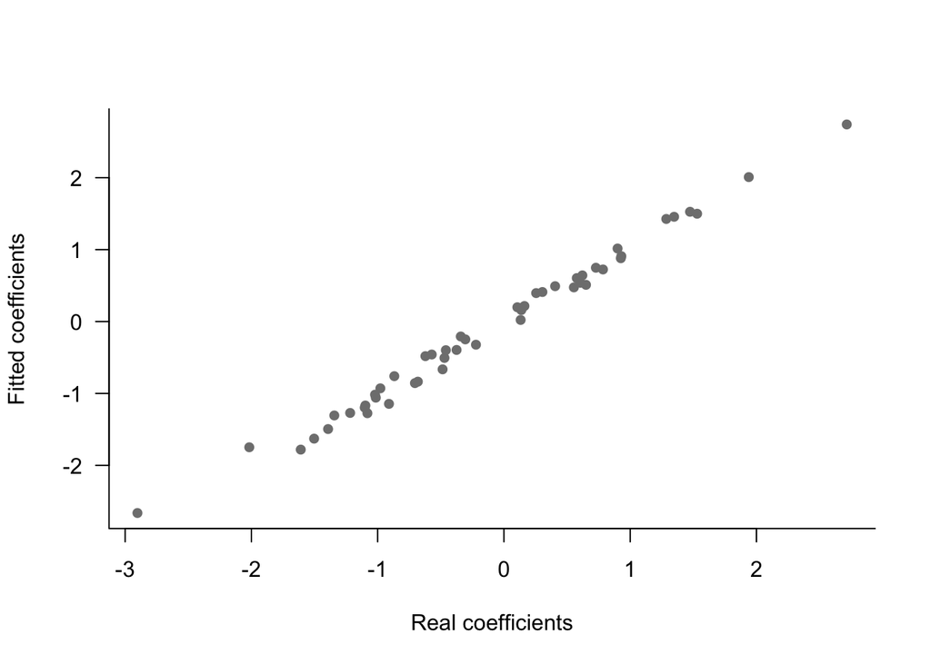

```r
# plot fitted coefficients against real coefficients
plot(fitted_coef ~ beta_real,
     pch = 16, col = 'gray50', bty = 'l', las = 1,
     ylab = 'Fitted coefficients',
     xlab = 'Real coefficients')
```

## Running code in parallel

The logistic regression example has multiple, independent function calls (the calls to `glm`) and is well-suited to parallelisation. So how can we do this?

### Step 1: using `*apply` functions

Most of the packages for parallel R use variations on the `*apply` family of functions (e.g. `lapply`, `sapply`). Learning how to use these functions is the key to simple parallel computing in R. We can use the `lapply` function to fit our logistic regression without using the `for` loop.

```r
# we need to wrap our glm call in a function
mod_fun <- function(i, y, x) {
  glm(y[, i] ~ -1 + x, family = stats::binomial)
}

# we can use the lapply function to call mod_fun repeatedly for different values of i
mod_lapply <- lapply(1:nsp, mod_fun, y = y, x = x)

# extract fitted coefficients
fitted_coef_lapply <- sapply(mod_lapply, function(x) x$coefficients)

# compare these to the model fitted with a for loop
all.equal(c(fitted_coef_lapply), c(fitted_coef))
```

```
## [1] TRUE
```

The `lapply` function fits the model for each species independently. This will only work if your problem is embarrassingly parallel (i.e. fitting a model for one species doesn’t depend on fitted models for the other species). If this is the case, it is straightforward to run the components of this `lapply` call in parallel.

### Step 2: running `lapply` in parallel

#### Some basics

First, we need to load the `parallel` package.

```r
library(parallel)
```

As the name suggests, the parallel package can be used to run R code in parallel. It has some handy helpers, such as a function to tell you how many cores you have access to.

```r
detectCores()
```

```
## [1] 4
```

This number isn’t necessarily the number of processors you have in your system, but it’s a good guide to how many cores R can take advantage of. It’s worth noting two things. First, trying to trick R to use more cores than you have isn’t going to give you any benefit. Second, it’s not a great idea to use all of your available cores for an R analysis because other programs might need access to a core while R is running.

#### Approaches to parallelising R code

There are two main ways to parallelise your R code: using *sockets* or by *forking*. These are quite different approaches and each has its own pros and cons.

Using *sockets* launches a new R session on each core, similar to opening up multiple R windows on your desktop. Each R session will be empty (it won’t contain anything from your current R workspace). *Forking* splits your current R session across multiple cores, making your current workspace available to each core.

Using *sockets* requires a bit more effort than *forking*, but is necessary if you want to run R code in parallel on Windows. *Forking* only works on POSIX systems (e.g. OSX, Linux, Unix). Although a *socket* approach takes a bit more effort, it can be very powerful. For example, it will work across a network where nodes are spread across multiple computers in different locations. *Forking* won’t work in this case, but is extremely easy to set up, and will often be faster (and use less RAM) than the *socket* approach.

#### Step 2a: using *forking* to parallelise R code

Note: this will not run in parallel on Windows computers. The functions will run but will behave like the standard `lapply` function.

```r
# simply change the lapply call from above to an mclapply call;
#  the mc.cores argument tells R how many cores to use
mod_mc <- mclapply(1:nsp, mod_fun, y = y, x = x, mc.cores = 3)

# extract fitted coefficients
fitted_coef_mc <- sapply(mod_mc, function(x) x$coefficients)

# compare these to the model fitted with a for loop
all.equal(c(fitted_coef_mc), c(fitted_coef))
```

```
## [1] TRUE
```

#### Step 2b: using a *socket* approach to parallelise R code

This approach is a bit more involved than the previous example but will work on all computers.

```r
# we need to set up a cluster with all the cores we want to use
cl <- makeCluster(3)  # set up a cluster that can run three processes

# each process is an empty R session, so we need to pass all our data and
#   functions to each process. We can do this with the clusterExport function
clusterExport(cl, c('mod_fun', 'y', 'x'))

# we can then use a *apply function to fit our model in parallel
mod_sock <- parLapply(cl = cl, 1:nsp, mod_fun, y, x)

# finally, we need to shut down the cluster (equivalent to closing the R session)
stopCluster(cl)

# extract fitted coefficients
fitted_coef_sock <- sapply(mod_sock, function(x) x$coefficients)

# compare these to the model fitted with a for loop
all.equal(c(fitted_coef_sock), c(fitted_coef))
```

```
## [1] TRUE
```

## Comparing the different approaches

There are four broad approaches introduced above to fit multiple, independent logistic regressions: (1) use a for loop; (2) use `lapply`; (3) use *forking* with `mclapply`; or (4) use a *socket* approach with `parLapply`.

These approaches will perform differently under different scenarios. For our data simulated above (1000 observations, 10 species, 5 predictor variables):

```r
# for loop
system.time({
  mod <- vector('list', length = nsp)
  for (i in 1:nsp) {
    mod[[i]] <- mod_fun(i, y = y, x = x)
  }
})
```

```
##    user  system elapsed
##   0.049   0.006   0.056
```

```r
# lapply function
system.time({
  mod_lapply <- lapply(1:nsp, mod_fun, y = y, x = x)
})
```

```
##    user  system elapsed
##   0.048   0.007   0.056
```

```r
# mclapply function
system.time({
  mod_mc <- mclapply(1:nsp, mod_fun, y = y, x = x, mc.cores = 3)
})
```

```
##    user  system elapsed
##   0.204   0.140   0.104
```

```r
# parLapply function
system.time({
  cl <- makeCluster(3)
  clusterExport(cl, c('mod_fun', 'y', 'x'))
  mod_sock <- parLapply(cl = cl, 1:nsp, mod_fun, y, x)
  stopCluster(cl)
})
```

```
##    user  system elapsed
##   0.062   0.019   0.948
```

Here, the non parallelised versions actually perform faster than the parallelised versions. This is because there is overhead associated with setting up the cluster and fitting models on separate cores. For simple functions, this overhead is greater than the time it takes to run the function, so non-parallelised code runs faster. This is not the case if the individual models take much longer to run.

```r
# modify our model function to pause after each model fitting
mod_fun2 <- function(i, y, x) {
  Sys.sleep(2)
  glm(y[, i] ~ -1 + x, family = stats::binomial)
}

# for loop
system.time({
  mod2 <- vector('list', length = nsp)
  for (i in 1:nsp) {
    mod2[[i]] <- mod_fun2(i, y = y, x = x)
  }
})
```

```
##    user  system elapsed
##   0.091   0.010  20.132
```

```r
# lapply function
system.time({
  mod_lapply2 <- lapply(1:nsp, mod_fun2, y = y, x = x)
})
```

```
##    user  system elapsed
##   0.080   0.005  20.115
```

```r
# mclapply function
system.time({
  mod_mc2 <- mclapply(1:nsp, mod_fun2, y = y, x = x, mc.cores = 3)
})
```

```
##    user  system elapsed
##   0.156   0.120   8.117
```

```r
# parLapply function
system.time({
  cl <- makeCluster(3)
  clusterExport(cl, c('mod_fun2', 'y', 'x'))
  mod_sock2 <- parLapply(cl = cl, 1:nsp, mod_fun2, y, x)
  stopCluster(cl)
})
```

```
##    user  system elapsed
##   0.057   0.019   8.843
```

With a 2 second pause after each model is fitted (a cheat’s way to make the model “harder” to fit), the parallel functions start to outperform the serial alternatives. These speed-ups will be more substantial for models that take even longer to fit. The *forking* and *socket* approaches perform similarly here, which is not always the case. The *socket* approach is typically slower than the *forking* approach.

## Issues that can arise when running R code in parallel

### Using too much RAM or too many cores

Running a lot of processes at the same time has one major risk: using too many resources. Each process uses at least one core and each process uses some RAM. If the processes use all of the available cores, or the memory use of all processes exceeds the total available RAM, then it’s likely that your system will crash or run very slowly. The number of cores is easy to control using the `mc.cores` argument in `mclapply` or by setting up your cluster appropriately when using `parLapply`. A common rule is to use one less core than you have available (e.g. `mc.cores = (detectCores() - 1)` or `cl <- makeCluster((detectCores() - 1))`). This is fine on your own computer but it isn’t a great idea on compute servers (e.g. Boab), where the cores often need to be shared among multiple users.

Memory usage can be controlled in several ways. First, you can limit the number of cores used so that the total memory needed for all processes is less than the limit (usually 8-16GB, can be much higher on servers). Second, using *forking* (where possible) will reduce memory usage because the forked processes all link back to the original memory address for any variables created before the parallel call. By contrast, the *socket* approach requires copies of each variable (passed with the `clusterExport()` function) in each process. Third, avoiding unnecessary copies of variables within your parallel processes will reduce memory usage. And example of this is

```r
par_fun <- function(x) {
  x2 <- x + 1  ## unnecessary
  mean(x2)
}
```

which uses twice the memory needed because there are two copies of essentially the same variable (`x` and `x2`). A better alternative is

```r
par_fun <- function(x) {
  mean((x + 1))
}
```

which avoids the extra copy of `x`. Last, it can be useful to use rm() and gc() within functions to remove unnecessary objects and release memory that’s no longer needed. This is a bit more advanced, but there are some good examples in [Max Gordon’s r-bloggers post](https://www.r-bloggers.com/how-to-go-parallel-in-r-basics-tips/).

### *Forking* versus *sockets*

There are two issues that can arise when using *forking* because this approach shares your initial workspace across all processes. Both issues are unlikely to occur in standard examples (e.g. splitting a SDM across multiple cores).

First, it is unwise to try to reproduce random number streams using the `set.seed()` function when *forking* your R session. Calling `set.seed()` before *forking* would set all processes to the same RNG seed, and random number streams in each of these processes would then be identical. The `parallel` package avoids this issue by setting separate seeds for each process by default. The package vignettes and documentation go through how to work around this if you really need to.

Second, because *forking* shares rather than copies your workspace to each process, there is a risk of cross-contamination among processes. This is unlikely because R typically creates copies of variables when you pass them to a function. However, using global variables or passing variables by reference (e.g. with R6 classes or if you interface with C/C++) can create problems when *forking*. The `parallel` package seems to avoid this issue by throwing an error if you try to modify something in the shared workspace.

## Extensions

### Parallel computing for intermediate cases

The examples above involve running completely independent processes over multiple cores. Many analyses sit somewhere between completely independent and inherently serial. In this case, it is still possible to use parallel computing to speed up your analysis. The `greta` package has examples of this. `greta` uses Hamiltonian Monte Carlo, which is inherently serial. However, each iteration of the Monte Carlo sampler can involve quite complex calculations, and it’s possible to speed these up using parallel computing. This process can be quite complicated, especially if you want to make use of GPUs, so it’s typically easiest to let someone else do the heavy lifting. The use of GPUs is extremely well-suited to large matrix operations, and there are several packages containing GPU-ready R functions (e.g. `gputools`, `gmatrix`, `gpuR`). The `tensorflow` R package can make use of GPUs if you install the appropriate version of TensorFlow. In each of these cases, assuming you can get R speaking to your GPU correctly (e.g. using NVIDIA’s CUDA platform), you can set up parallel processing using slightly modified versions of standard R functions.

### The `foreach` function

The `foreach` function in the `foreach` package can be used for all the examples above, but allows you to write your parallel call as a for loop rather than using an `*apply` function. `foreach` works with *forking* or with a *socket* approach, and you specify which approach you want to use by “registering” a cluster. Our logistic regression example might look something like

```r
# load packages
library(foreach)
library(doParallel)
# set up a cluster
cl <- makeCluster(3)
registerDoParallel(cl)  # register the cluster
mod_foreach <- foreach(i = 1:nsp) %dopar%
                 mod_fun2(i, y = y, x = x)
stopCluster(cl)         # stop cluster

# extract fitted coefficients
fitted_coef_foreach <- sapply(mod_foreach, function(x) x$coefficients)

# compare these to the model fitted with a for loop
all.equal(c(fitted_coef_foreach), c(fitted_coef))
```

```
## [1] TRUE
```

```r
# time this approach
system.time({
cl <- makeCluster(3)
registerDoParallel(cl)
mod_foreach <- foreach(i = 1:nsp) %dopar%
                 mod_fun2(i, y = y, x = x)
stopCluster(cl)
})
```

```
##    user  system elapsed
##   0.217   0.021   9.020
```

The `foreach` function is quite flexible and is relatively easy to use. [Max Gordon’s r-bloggers post](https://www.r-bloggers.com/how-to-go-parallel-in-r-basics-tips/) and the [`doParallel` vignette](https://cran.r-project.org/web/packages/doParallel/vignettes/gettingstartedParallel.pdf) both have good introductions to `foreach`.

### Using a HPC environment

The most basic form of parallel coding in R is to open multiple R sessions (possibly across several computers) and run different analyses in each. This is essentially what the `parLapply` function is doing. Systems like the University’s Spartan HPC service allow you to do this on a large scale, simply by submitting lots of separate jobs. You can take this further and submit multiple jobs, each running across several cores (e.g. fitting several MCMC models each with multiple chains running on separate cores). This approach is worth considering if you need a lot of cores or RAM (Boab is fine for this too, but doesn’t make it easy to schedule multiple jobs).